# Taller 2 - Componentes

Maria Piñeros

23/5/2021

## Punto 1

Los siguientes puntos deben realizarse posterior a la limpieza de valores atípicos. Indique los valores omitidos.

La base de datos punto 1 contiene 11 indicadores económicos y sociales de 96 países. Las variables observadas son:

X_1 = Tasa anual de crecimiento de la población,

X_2 = Tasa de mortalidad infantil por cada 1000 nacidos vivos.

X_3= Porcentaje de mujeres en la población activa.

X_4= PNB en 1995 (en millones de dólares).

X_5= Producción de electricidad (en millones kW/h).

X_6= Líneas telefónicas por cada 1000 habitantes,

X_7= Consumo de agua per cápita,

X_8= Proporción de la superficie del país cubierta por bosques,

X_9= Proporción de forestación anual,

X_10= Consumo de energía per cápita,

X_11= Emisión de CO2 per cápita.

### Descargar datos

```r
library(readxl)
setwd("C:/Users/ASUS/Desktop/Universidad")
Datos<- read_excel('Base punto 1.xlsx')
```

### Eliminamos los datos atípicos

Se realiza un análisis gráfico por medio de diagramas de caja para detectar datos atípicos o outliers, los cuales serán eliminados .

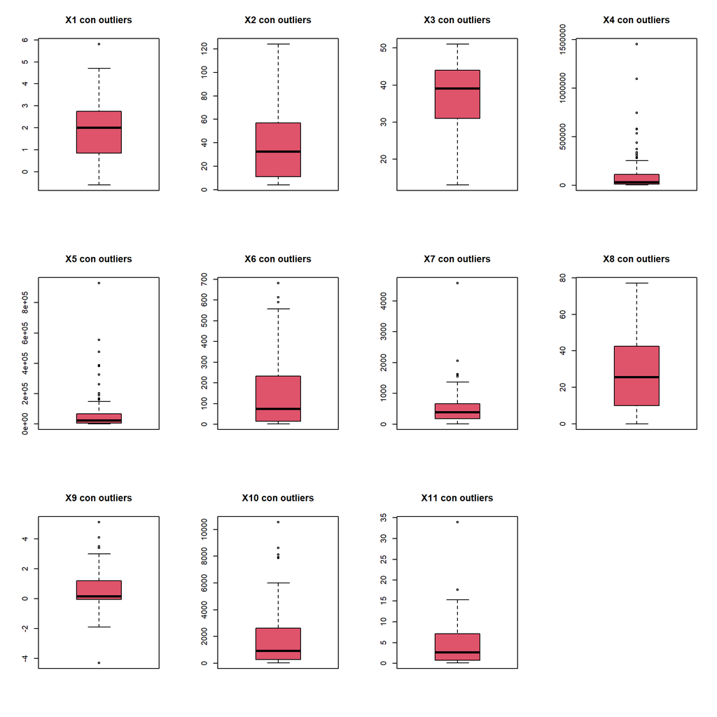

```r
par(mfrow=c(3,4))
boxplot(Datos$`X 1`, main = "X1 con outliers", col=2)
boxplot(Datos$`X 2`, main = "X2 con outliers", col=2)
boxplot(Datos$`X 3`, main = "X3 con outliers", col=2)
boxplot(Datos$`X 4`, main = "X4 con outliers", col=2)
boxplot(Datos$`X 5`, main = "X5 con outliers", col=2)
boxplot(Datos$`X 6`, main = "X6 con outliers", col=2)
boxplot(Datos$`X 7`, main = "X7 con outliers", col=2)
boxplot(Datos$`X 8`, main = "X8 con outliers", col=2)
boxplot(Datos$`X 9`, main = "X9 con outliers", col=2)
boxplot(Datos$`X 10`, main = "X10 con outliers", col=2)
boxplot(Datos$`X 11`, main = "X11 con outliers", col=2)
```

Luego, definimos una función para eliminar todos los datos atíticos que no se encuentren entre el cuantil 0,5 y 0,95

```r
impute_outliers <- function(x, removeNA = TRUE){
  quantiles <- quantile(x, c(0.05, 0.95), na.rm = removeNA)
  x[x<quantiles[1]] <- mean(x, na.rm = removeNA)
  x[x>quantiles[2]] <- median(x, na.rm = removeNA)
  x
}
```

```r
Datos$`X 1` <- impute_outliers(Datos$`X 1`,)
Datos$`X 2` <- impute_outliers(Datos$`X 2`,)
Datos$`X 3` <- impute_outliers(Datos$`X 3`,)
Datos$`X 4` <- impute_outliers(Datos$`X 4`,)
Datos$`X 5` <- impute_outliers(Datos$`X 5`,)
Datos$`X 6` <- impute_outliers(Datos$`X 6`,)
Datos$`X 7` <- impute_outliers(Datos$`X 7`,)
Datos$`X 8` <- impute_outliers(Datos$`X 8`,)
Datos$`X 9` <- impute_outliers(Datos$`X 9`,)
Datos$`X 10` <- impute_outliers(Datos$`X 10`,)
Datos$`X 11` <- impute_outliers(Datos$`X 11`,)
```

De esta forma, al volver a graficar los diagramas de caja después de eliminar los datos atípicos tenemos que:

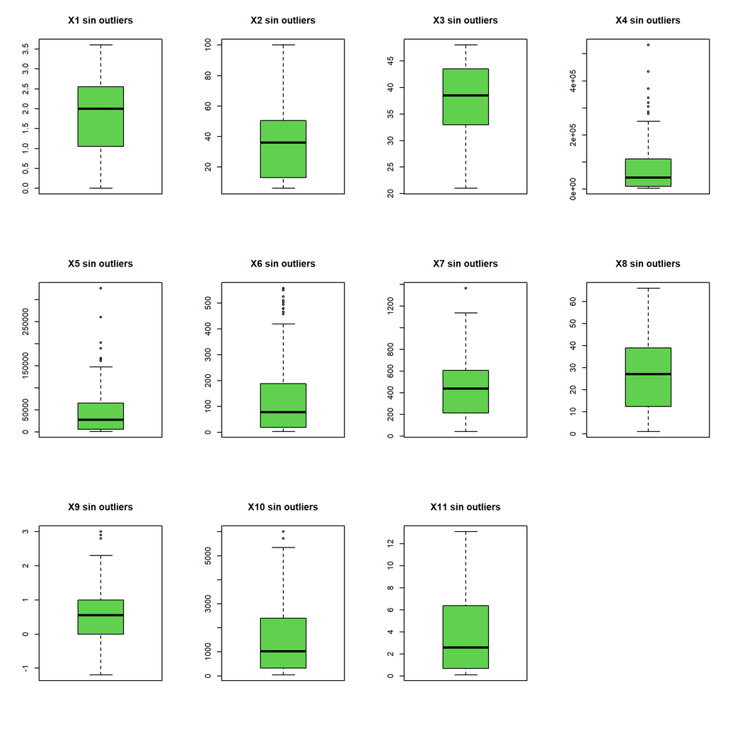

### Estadística descriptiva

.

### 1. Análisis de correlación

MEdiante un cuadro de correlación analizaremos las varibales con mayor coeficiente de correlación

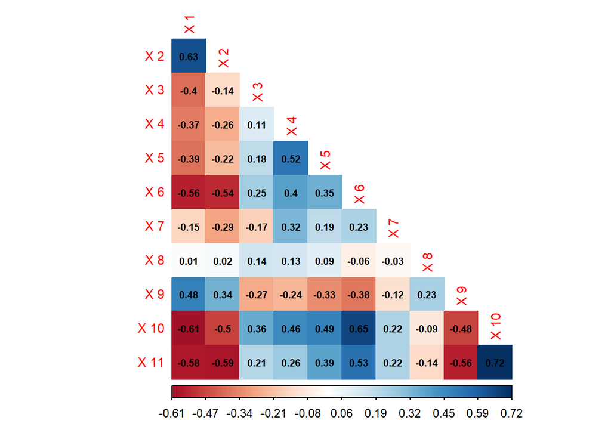

```r
library(corrplot)
library(dplyr)
Datos <- Datos %>%
  select("X 1":"X 11")
corrplot::corrplot(cor(Datos),
                   method="color",
                   type="lower",
                   number.cex=0.7,
                   addCoef.col = "black",
                   tl.col="red",
                   tl.srt=90,
                   tl.cex = 0.9,
                   diag=FALSE,
                   is.corr = F)
```

Mediante esta matriz, seleccionamos unicamente las varibales que se correlacionen a un grado igual o mayor de 0,5 con 3 variables o más.

De este modo sólo quedan las variables:

X1, X2, X6, X10, X11

```r
Datos<- Datos %>%
  select("X 1", "X 2","X 6", "X 10", "X 11")
```

### 2. Test de barlett

```r
library(psych)
cortest.bartlett(Datos,n=96)
```

```
## R was not square, finding R from data
```

```
## $chisq
## [1] 239.2585
##
## $p.value
## [1] 9.804989e-46
##
## $df
## [1] 10
```

Note que el p valor es menor al 0.05. Por tanto se rechaza a favor de la hipotesis alternativa. De este modo al menos dos varianzas son diferentes.

### 3. Gráfico de sedimentaci+on y varianza acumulada

```r
cpe<-prcomp(Datos,scale=T)
names(cpe)
```

```
## [1] "sdev"     "rotation" "center"   "scale"    "x"
```

#### 3.1 GRáfico de sedimentación

```r
library("factoextra")
```

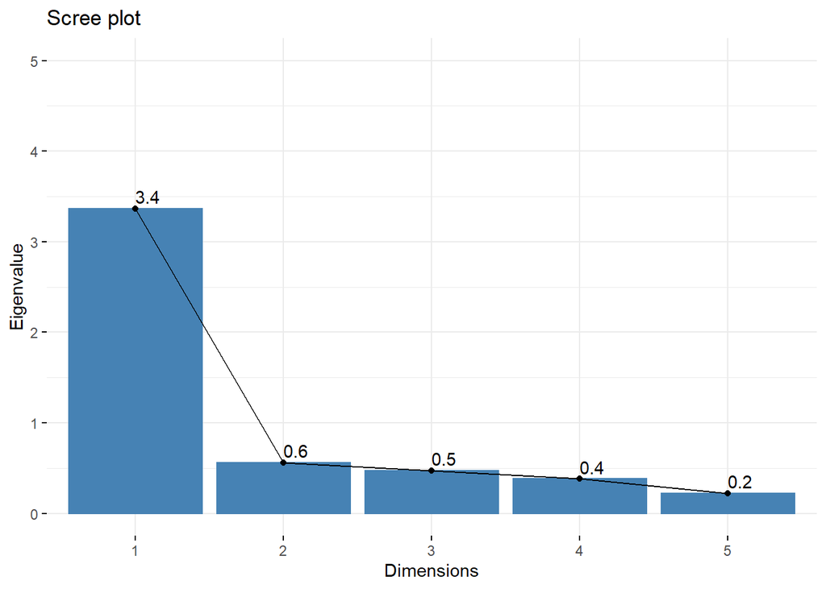

```r
fviz_eig(cpe,choice = "eigenvalue", addlabels = TRUE, axes = 1,ylim = c(0,5))
```

Note que únicamente 1 barra es mayor a 1. Por tanto, me recomienda analizar 1 solo componente. Esto con la consideración que igualmente tendremos el 68% de la información.

#### 3.2 Varianza acumulada

```r
library(ggplot2)
prop_varianza <- cpe$sdev^2 / sum(cpe$sdev^2);prop_varianza*100
```

```
## [1] 67.292575 11.221694  9.429866  7.611452  4.444413
```

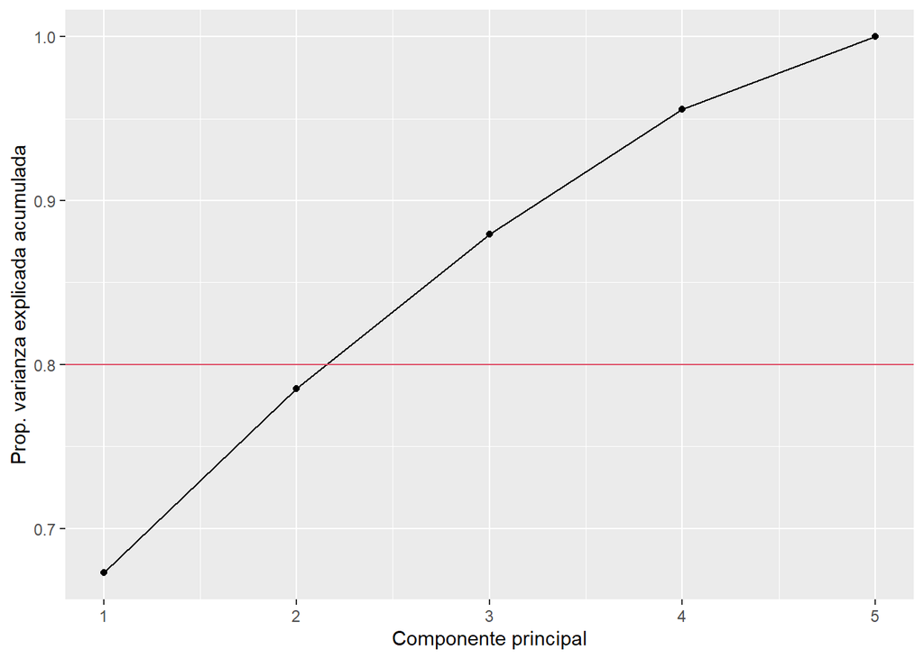

```r
prop_varianza_acum <- cumsum(prop_varianza)
ggplot(data = data.frame(prop_varianza_acum, pc=1:5),
       aes(x = pc, y = prop_varianza_acum, group = 1)) +
  geom_point() +
  geom_line() +
  labs(x = "Componente principal",
       y = "Prop. varianza explicada acumulada")+geom_hline(yintercept=0.8,col=2)
```

Este criterio me recomienda usar 3 componentes, ya que son los que superan el 0.8 en la gráfica de varianza acumulada.

Encontramos que X1 y X2 están correlacionadas y X6, X10 y X11 están correlacioandas igualmente en dirección diferente. Graficamente podríamos sugerir que X2 y X10 tienen mayor poder explicativo.

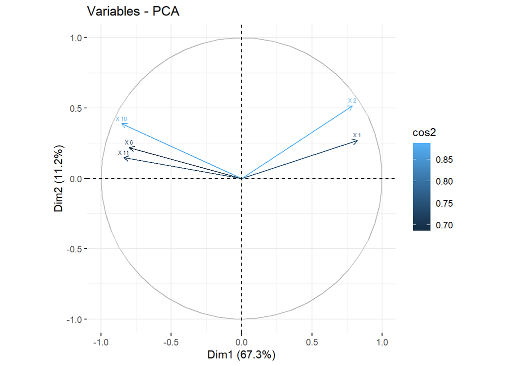

```r
fviz_pca_var(cpe, col.var = "cos2",
             geom.var = c("arrow", "text"),
             labelsize = 2,
             repel = FALSE)
```

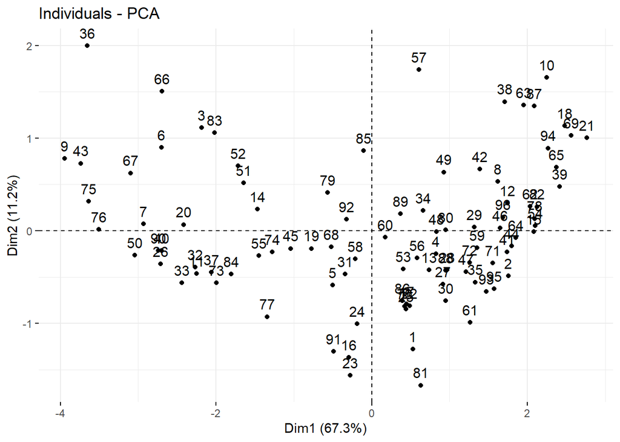

```r
fviz_pca_ind(cpe,addEllipses=F)
```

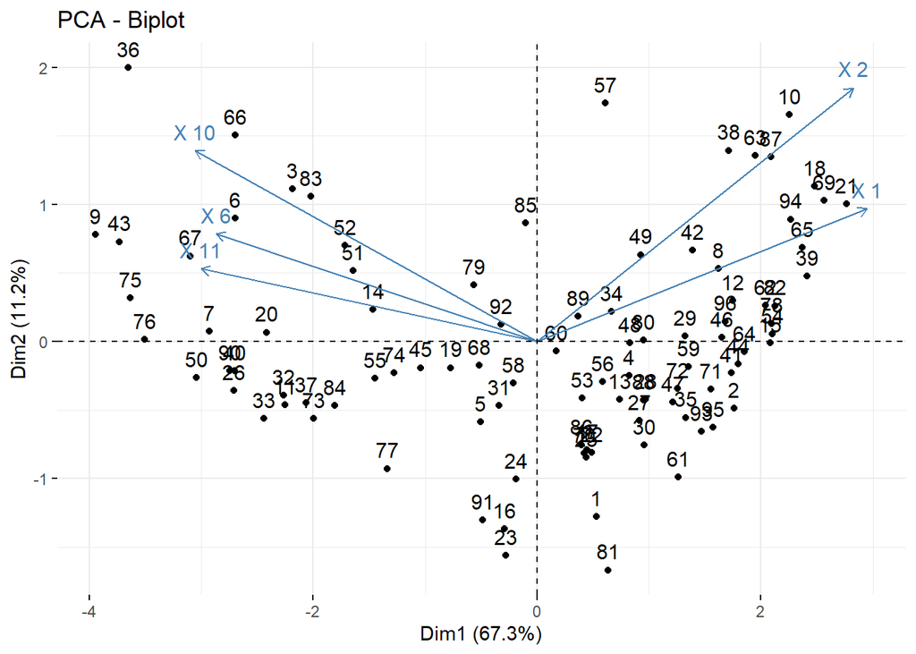

```r
fviz_pca_biplot(cpe)
```